# Prediction Assignment

STP

12/16/2020

```r
knitr::opts_chunk$set(echo = TRUE)
knitr::opts_chunk$set(fig.path = "figs/fig-")
library(caret)
library(dplyr)
library(randomForest)
library(rpart)
library(rattle)
library (RCurl)
set.seed(12345)
```

## Getting the Data

The data for this assigment was downloaded from the URLs given in the assignment. Information about these data was found here: http://web.archive.org/web/20161224072740/http:/groupware.les.inf.puc-rio.br/har

These data contain motion variables from sensors placed on the subjects’ upper arm, forearm, and belt, as well as information from the dumbbell. The column “classe” indicates how the movement was executed, and is what our model must predict for the test set. The R code below indicates that classe is a character variable and has five unique values: A, B, C, D, and E. The web site above indicates that A corresponds to correct execution of the exercise, while the other 4 options correspond to different incorrect executions of the exercise. The classe needs to be converted to a factor variable for later methods to work.

```r
traindl <- getURL("https://d396qusza40orc.cloudfront.net/predmachlearn/pml-training.csv")
training <- read.csv (text = traindl)

testdl <- getURL("https://d396qusza40orc.cloudfront.net/predmachlearn/pml-testing.csv")
testing <- read.csv (text = testdl)

str(training)
```

```
## 'data.frame':    19622 obs. of  160 variables:
##  $ X                       : int  1 2 3 4 5 6 7 8 9 10 ...
##  $ user_name               : chr  "carlitos" "carlitos" "carlitos" "carlitos" ...
##  $ raw_timestamp_part_1    : int  1323084231 1323084231 1323084231 1323084232 1323084232 1323084232 1323084232 1323084232 1323084232 1323084232 ...
##  $ raw_timestamp_part_2    : int  788290 808298 820366 120339 196328 304277 368296 440390 484323 484434 ...
##  $ cvtd_timestamp          : chr  "05/12/2011 11:23" "05/12/2011 11:23" "05/12/2011 11:23" "05/12/2011 11:23" ...
##  $ new_window              : chr  "no" "no" "no" "no" ...
##  $ num_window              : int  11 11 11 12 12 12 12 12 12 12 ...
##  $ roll_belt               : num  1.41 1.41 1.42 1.48 1.48 1.45 1.42 1.42 1.43 1.45 ...
##  $ pitch_belt              : num  8.07 8.07 8.07 8.05 8.07 8.06 8.09 8.13 8.16 8.17 ...
##  $ yaw_belt                : num  -94.4 -94.4 -94.4 -94.4 -94.4 -94.4 -94.4 -94.4 -94.4 -94.4 ...
##  $ total_accel_belt        : int  3 3 3 3 3 3 3 3 3 3 ...
##  $ kurtosis_roll_belt      : chr  "" "" "" "" ...
##  $ kurtosis_picth_belt     : chr  "" "" "" "" ...
##  $ kurtosis_yaw_belt       : chr  "" "" "" "" ...
```

[output cut: 86 more lines]

```r
class(training$classe)
```

```
## [1] "character"
```

```r
unique(training$classe)
```

```
## [1] "A" "B" "C" "D" "E"
```

```r
## must convert classe in the training set to a factor variable
training <- mutate(training, classe = as.factor(classe))
```

## Cleaning the Data

The data sets contain 160 variables, which will be too many to use for the prediction models based on computation.

First, we will remove columns with very little variance because variables without variance will not be useful in making predictions.

```r
myDataNZV <- nearZeroVar(training, saveMetrics=TRUE)
cols <- filter(myDataNZV, nzv == "TRUE")
NZVcols <- row.names(cols)
mytraining <- select(training, -all_of(NZVcols))
mytesting <- select(testing, -all_of(NZVcols))
```

Next, we will remove columns that have a large number of NA values, as these will not be useful in the prediction analysis.

```r
# Function to remove columns with > 60% NA
removedNAsColumns <- function(df) {
  numRows <- nrow(df)
  missingDf <- is.na(df)
  removedColumns = which(colSums(missingDf) > numRows*60/100)
  # might be possible that none of the columns meet the threshold
  if (length(removedColumns) > 0) {
    colNames <- names(removedColumns)
    df <- select(df, -all_of(colNames))
  }
  df
}

## applying this function does assume that the same columns in the training and test sets will have >60% NAs
mytraindf <- removedNAsColumns(mytraining)
mytestdf <- removedNAsColumns(mytesting)
```

To confirm that the same columns were removed from each data frame, we compare the column names to each other. The last column in the two data frames is different, so we expect one column name to differ between the two data frames.

```r
x <- colnames(mytraindf)
y <- colnames(mytestdf)
both <- x == y
a <- ncol(mytraindf)
b <- ncol(mytestdf)
c <- sum(both)
```

The processed training data set has 59 columns, the processed testing data set has 59 columns, and the two data sets share 58 column names in common, which is what was expected.

Looking at the column names in the data frames, we can see there are some columns that will not contribute meaningfully to the prediction, such as X, the user name, and various time stamps. These columns are removed.

```r
mytraindf <- select(mytraindf, -c(1:6))
mytestdf <- select(mytestdf, -c(1:6))
```

## Create a Partition in the Training Set

The training set was split into a training set and a testing set withint the larger training set in order to use model stacking in the prediction process.

```r
set.seed(12345)
inTrain = createDataPartition(mytraindf$classe, p = 3/4)[[1]]
train1 = mytraindf[ inTrain,]
test1 = mytraindf[-inTrain,]
```

## Creating Models to Predict classe

## Random Forest Model

First, a Random Forest Model is applied to the training set.

```r
rfModel <- randomForest(classe~., data=train1)
rfModel
```

```
##
## Call:
##  randomForest(formula = classe ~ ., data = train1)
##                Type of random forest: classification
##                      Number of trees: 500
## No. of variables tried at each split: 7
##
##         OOB estimate of  error rate: 0.46%
## Confusion matrix:
##      A    B    C    D    E  class.error
## A 4183    2    0    0    0 0.0004778973
## B   11 2830    7    0    0 0.0063202247
## C    0   14 2549    4    0 0.0070120764
## D    0    0   24 2388    0 0.0099502488
## E    0    0    4    2 2700 0.0022172949
```

This model is used to predict outcomes for the “test” set that is really part of the original training set.

```r
RFpred <- predict(rfModel, newdata = test1)
RFConMat <- confusionMatrix(RFpred, test1$classe)
RFConMat
```

```
## Confusion Matrix and Statistics
##
##           Reference
## Prediction    A    B    C    D    E
##          A 1395    1    0    0    0
##          B    0  948    3    0    0
##          C    0    0  851   12    0
##          D    0    0    1  787    1
##          E    0    0    0    5  900
##
## Overall Statistics
##
##                Accuracy : 0.9953
##                  95% CI : (0.993, 0.997)
##     No Information Rate : 0.2845
##     P-Value [Acc > NIR] : < 2.2e-16
##
##                   Kappa : 0.9941
##
##  Mcnemar's Test P-Value : NA
##
## Statistics by Class:
##
##                      Class: A Class: B Class: C Class: D Class: E
## Sensitivity            1.0000   0.9989   0.9953   0.9789   0.9989
## Specificity            0.9997   0.9992   0.9970   0.9995   0.9988
## Pos Pred Value         0.9993   0.9968   0.9861   0.9975   0.9945
## Neg Pred Value         1.0000   0.9997   0.9990   0.9959   0.9997
## Prevalence             0.2845   0.1935   0.1743   0.1639   0.1837
## Detection Rate         0.2845   0.1933   0.1735   0.1605   0.1835
## Detection Prevalence   0.2847   0.1939   0.1760   0.1609   0.1845
## Balanced Accuracy      0.9999   0.9991   0.9962   0.9892   0.9988
```

```r
RFAcc <- RFConMat$overall[1]
```

The accuracy of the random forest predictor is 0.99531 when applied to the test partition of the training set.

## Decision Tree Model

Then a decision tree model is fit to the training set.

```r
set.seed(12345)
dtModel <- train(classe ~ .,method="rpart",data=train1)
dtModel
```

```
## CART
##
## 14718 samples
##    52 predictor
##     5 classes: 'A', 'B', 'C', 'D', 'E'
##
## No pre-processing
## Resampling: Bootstrapped (25 reps)
## Summary of sample sizes: 14718, 14718, 14718, 14718, 14718, 14718, ...
## Resampling results across tuning parameters:
##
##   cp          Accuracy   Kappa
##   0.03436818  0.5088171  0.35920012
##   0.06129941  0.4229360  0.22029825
##   0.11601633  0.3294723  0.06908774
##
## Accuracy was used to select the optimal model using the largest value.
## The final value used for the model was cp = 0.03436818.
```

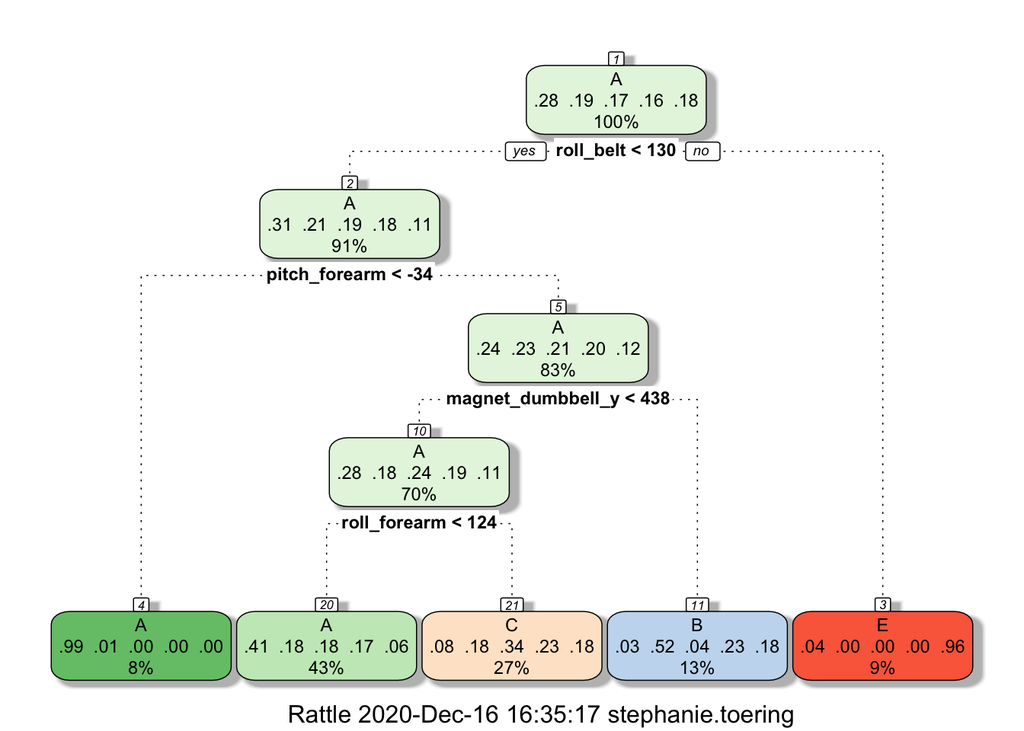

```r
fancyRpartPlot(dtModel$finalModel)
```

This model is used to predict outcomes for the “test” set that is really part of the original training set.

```r
DTpred <- predict(dtModel, newdata = test1)
DTConMat <- confusionMatrix(DTpred, test1$classe)
DTConMat
```

```
## Confusion Matrix and Statistics
##
##           Reference
## Prediction    A    B    C    D    E
##          A 1252  396  434  343  114
##          B   30  317   24  151  132
##          C   90  236  397  310  229
##          D    0    0    0    0    0
##          E   23    0    0    0  426
##
## Overall Statistics
##
##                Accuracy : 0.4878
##                  95% CI : (0.4737, 0.5019)
##     No Information Rate : 0.2845
##     P-Value [Acc > NIR] : < 2.2e-16
##
##                   Kappa : 0.3306
##
##  Mcnemar's Test P-Value : NA
##
## Statistics by Class:
##
##                      Class: A Class: B Class: C Class: D Class: E
## Sensitivity            0.8975  0.33404  0.46433   0.0000  0.47281
## Specificity            0.6332  0.91479  0.78637   1.0000  0.99425
## Pos Pred Value         0.4931  0.48471  0.31458      NaN  0.94878
## Neg Pred Value         0.9395  0.85129  0.87424   0.8361  0.89338
## Prevalence             0.2845  0.19352  0.17435   0.1639  0.18373
## Detection Rate         0.2553  0.06464  0.08095   0.0000  0.08687
## Detection Prevalence   0.5177  0.13336  0.25734   0.0000  0.09156
## Balanced Accuracy      0.7654  0.62441  0.62535   0.5000  0.73353
```

```r
DTAcc <- DTConMat$overall[1]
```

The accuracy of the decision tree predictor is 0.4877651 when applied to the test partition of the training set. This is poor accuracy for prediction, so the Random Forest method will be used to predict outcomes of the actual test set. Originally, I had planned to stack the two models to improve the outcome, but given the very high accuracy of the random forest method when applied to the “test” set within the training set and the low accuracy for the decision tree model, stacking the models seems unlikely to improve the overall predictions.

## Predictions for the Test Set

The Random Forest model was used to predict the classe for the observations for the test set.

```r
pred <- predict(rfModel, newdata = mytestdf)
pred
```

```
##  1  2  3  4  5  6  7  8  9 10 11 12 13 14 15 16 17 18 19 20
##  B  A  B  A  A  E  D  B  A  A  B  C  B  A  E  E  A  B  B  B
## Levels: A B C D E
```